# Circular statistics

Tobias Stephan

2026-11-02

This vignette teaches you how to retrieve statistical parameters of orientation data, for example the mean direction of stress datasets.

```r
library(tectonicr)
library(ggplot2) # load ggplot library
```

## Orientation data types

Circular orientation data are two-dimensional orientation vectors that are either **directional** or **axial**.

- **Directional** data are $2\pi$-periodical, the angle $\alpha$ is non-symmetrical on a circle. The modulus of the angle is $2\pi$ (360°): $\alpha = \alpha~\text{mod}~2\pi$. Directional data usually involve processes where objects or particles were transported from one known place to another. Examples are wind direction, bird vanishing angles, plate motion, and fault slip directions.
- **Axial** data are $\pi$-periodical, i.e. each direction is considered as equivalent to the opposite direction, so that the angles $\alpha$ and $\alpha + 180^\circ$ are equivalent. The modulus of the angle is $\pi$ (180°): $\alpha = \alpha~\text{mod}~\pi$. Data usually involves transport of objects where the origin is unknown or doesn’t matter as the transport could be extended infinitely. Examples are glacial striae, mineral alignments (long-axis of grain or crystal shapes), and principal stress/strain axes (e.g. shortening or compression direction, including the angle of the maximum horizontal stress $\sigma_\text{Hmax}$).

> In (almost) every function in the **tectonicr** library, the `axial` argument specifies whether your angles `x` are axial (`TRUE`) or directional (`FALSE`). Because this package is mainly designed for analyzing stress orientations, the default is `axial=TRUE`.

[figure not shown]

```r
angles <- rvm(10, mean = 35, kappa = 20)

par(mfrow = c(1, 2), xpd = NA)
circular_plot(main = "Directional")
rose_line(angles, axial = FALSE, col = "#B63679FF")

circular_plot(main = "Axial")
rose_line(angles, axial = TRUE, col = "#B63679FF")
```

## Mean direction

In case of axial data, the calculation of the mean of, say, of 35$^{\circ}$ and 355$^{\circ}$ should be 15 instead of 195$^{\circ}$. **tectonicr** provides the circular mean (`circular_mean()`) and the quasi-median (`circular_median()`) as metrics to describe average direction:

```r
data("san_andreas")
circular_mean(san_andreas$azi)
```

```
#> [1] 10.64134
```

```r
circular_median(san_andreas$azi)
```

```
#> [1] 35.5
```

> Again: if your angles are directional, you need to specify the `axial` argument.

Note the different results:

```r
circular_mean(san_andreas$azi, axial = FALSE)
```

```
#> [1] 53.66556
```

```r
circular_median(san_andreas$azi, axial = FALSE)
```

```
#> [1] 36.5
```

## Quality weighted mean direction

Because the stress data is heteroscedastic, the data with less precise direction should have less impact on the final mean direction The weighted mean or quasi-median uses the reported measurements linear weighted by the inverse of the uncertainties:

```r
w <- weighting(san_andreas$unc)

circular_mean(san_andreas$azi, w)
```

```
#> [1] 10.85382
```

```r
circular_median(san_andreas$azi, w)
```

```
#> [1] 35.53572
```

The spread of directional data can be expressed by the standard deviation (for the mean) or the quasi-interquartile range (for the median):

```r
circular_sd(san_andreas$azi, w) # standard deviation
```

```
#> [1] 23.84385
```

```r
circular_IQR(san_andreas$azi, w) # interquartile range
```

```
#> [1] 35
```

## Statistics in the Pole of Rotation (PoR) reference frame

**NOTE:** Because the $\sigma_{SHmax}$ orientations are subjected to angular distortions in the geographical coordinate system, it is recommended to express statistical parameters using the transformed orientations of the PoR reference frame.

```r
data("cpm_models")
por <- cpm_models[["NNR-MORVEL56"]] |>
  equivalent_rotation("na", "pa")
san_andreas.por <- PoR_shmax(san_andreas, por, type = "right")
```

```r
circular_mean(san_andreas.por$azi.PoR, w)
```

```
#> [1] 139.7927
```

```r
circular_sd(san_andreas.por$azi.PoR, w)
```

```
#> [1] 22.49684
```

```r
circular_median(san_andreas.por$azi.PoR, w)
```

```
#> [1] 135.6247
```

```r
circular_IQR(san_andreas.por$azi.PoR, w)
```

```
#> [1] 25.89473
```

The collected summary statistics can be quickly obtained by `circular_summary()`:

```r
circular_summary(san_andreas.por$azi.PoR, w, mode = TRUE)
```

```
#>            n         mean           sd          var          25% quasi-median
#> 1126.0000000  139.7927014   22.4968398    0.2653334  123.5288513  135.6247317
#>          75%       median         mode           CI     skewness     kurtosis
#>  149.4235849  137.4843360  138.0821918    5.1165083   -0.2890426    1.6306589
#>            R
#>    0.7346666
```

The summary statistics additionally include the circular quasi-quantiles, the variance, the skewness, the kurtosis, the mode, the 95% confidence angle, and the mean resultant length (R).

## Rose diagram

**tectonicr** provides a rose diagram, i.e. histogram for angular data.

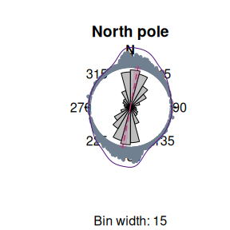

```r
rose(san_andreas$azi,
  weights = w, main = "North pole",
  dots = TRUE, stack = TRUE, dot_cex = 0.5, dot_pch = 21
)

# add the density curve as a corona plot:
plot_density(san_andreas$azi, kappa = 20, col = "#51127CFF", scale = 1.1, shrink = 2, xpd = NA)
```

The diagram shows

Showing the distribution of the transformed data gives the better representation of the angle distribution as there is no angle distortion due to the arbitrarily chosen geographic coordinate system.

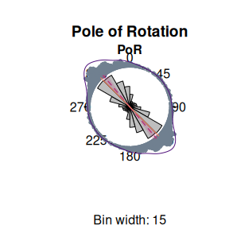

```r
# rose diagram
rose(san_andreas.por$azi,
  weights = w, main = "Pole of Rotation", origin.text = "PoR",
  dots = TRUE, stack = TRUE, dot_cex = 0.5, dot_pch = 21
)
# add density corona
plot_density(san_andreas.por$azi, kappa = 20, col = "#51127CFF", scale = 1.1, shrink = 2, xpd = NA)

# add predicted direction as streight line
rose_line(135, radius = 1.1, col = "#FB8861FF")
```

The orange line shows the predicted direction.

## QQ Plot

The (linearised) circular QQ-Plot (`circular_qqplot()`) can be used to visually assess whether our stress sample is drawn from an uniform distribution or has a preferred orientation.

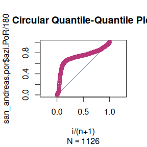

```r
circular_qqplot(san_andreas.por$azi.PoR)
```

Our data clearly deviates from the diagonal line, indicating the data is not randomly distributed and has a strong preferred orientation around the 50% quantile.

## Statistical tests

### Test for random distribution

Uniformly distributed orientation can be described by the *von Mises distribution*[^1]. If the directions are distributed randomly can be tested with the **Rayleigh Test**:

```r
rayleigh_test(san_andreas.por$azi.PoR)
```

```
#> Reject Null Hypothesis
#>
#>  Rayleigh test of uniformity
#>
#> data:  san_andreas.por$azi.PoR
#> S = 570.53, n = 1126, p-value < 2.2e-16
#> alternative hypothesis: unimodal distribution with an unknown mean direction
#> sample estimates:
#>           R        Rbar
#> 801.5102806   0.7118209
```

Here, the test rejects the Null Hypothesis (`statistic > p.value`). Thus the $\sigma_{SHmax}$ directions have a preferred orientation.

Alternative statistical tests for circular uniformity are `kuiper_test()` and `watson_test()`. Read `help()` for more details…

## Test for goodness-of-fit

### Confidence intervals

Assuming a von Mises Distribution (circular normal distribution) of the orientation data, a $100(1-\alpha)\%$ **confidence interval**[^2] can be calculated:

```r
confidence_interval(san_andreas.por$azi.PoR, conf.level = 0.95, w = w)
```

```
#> $mu
#> [1] 139.7927
#>
#> $conf.angle
#> [1] 5.116508
#>
#> $conf.interval
#> [1] 134.6762 144.9092
```

The prediction for the $\sigma_{SHmax}$ orientation is $135^{\circ}$. Since the prediction lies within the confidence interval, it can be concluded with 95% confidence that the orientations follow the predicted trend of $\sigma_{SHmax}$.

### Circular dispersion

The (weighted) **circular dispersion** of the orientation angles around the prediction is another way of assessing the significance of a normal distribution around a specified direction. The measure is based on the circular distance[^3] defined as
$$d = 1 - \cos{\left[ k(\theta -
\mu)\right]}$$
where $\theta$ are the observed angles (here $\sigma_{Hmax}$), $\mu$ is the theoretical angles, and $k=1$ for directional data and $k=2$ for directional data. The (weighted) dispersion[^4] is

$$D = \frac{1}{Z} \sum_{i=1}^{n} w_i
d_i$$
where $n$ s the number if observations, $w_i$ are weights of each observation, and $Z$ is the sum of all weights $Z=\sum_{i=1}^{n} w_i$.

It can be measured using `circular_dispersion()`:

```r
circular_dispersion(san_andreas.por$azi.PoR, y = 135, w = w)
```

```
#> [1] 0.1377952
```

The dispersion parameter yields a number in the range between 0 and 1 which indicates the quality of the fit. Low dispersion values ($D \le 0.15$) indicate good agreement between predicted and observed directions (angle difference $\le 22.5^\circ$ for axial data). High values ($D > 0.5$) indicate a systematic misfit between predicted and observed directions of about $> 45^\circ$ (axial data). A misfit of $90^\circ$ and/or a random distribution of results in $D = 1$.

The standard error and the confidence interval of the calculated circular dispersion can be estimated by bootstrapping via:

```r
circular_dispersion_boot(san_andreas.por$azi.PoR, y = 135, w = w, R = 1000)
```

[output not shown]

### Rayleigh Test

The statistical test for the goodness-of-fit is the (weighted) **Rayleigh Test**[^5] with a specified mean direction (here the predicted direction of $135^{\circ}$):

```r
weighted_rayleigh(san_andreas.por$azi.PoR, mu = 135, w = w)
```

```
#> Reject Null Hypothesis
#>
#>  Rayleigh V-test of uniformity
#>
#> data:  san_andreas.por$azi.PoR
#> S = 33.6, n_eff = 1075.7, p-value < 2.2e-16
#> alternative hypothesis: unimodal distribution with the specified mean direction 135
#> sample estimates:
#>         C
#> 0.7244095
```

Here, the Null Hypothesis is rejected, and thus, the alternative, i.e. an non-uniform distribution with the predicted direction as the mean cannot be excluded.

## Orientation tensor

For axial orientation data, summary statistics can also be expressed by the 2D orientation tensor. The orientation tensor is related to the moment of inertia given, that is minimized by calculating the Cartesian coordinates of the orientation data, and calculating their covariance matrix:

$$I =
\left[
\begin{array}{@{}cc@{}}
s_x^2 & s_{x,y} \\
s_{y,x} & s_y^2
\end{array}
\right] =
\left[
\begin{array}{@{}cc@{}}
\frac{1}{n}\sum\limits_{i=1}^{n} (x_i-0)^2 &
\frac{1}{n}\sum\limits_{i=1}^{n} (x_i-0)(y_i-0) \\
\frac{1}{n}\sum\limits_{i=1}^{n} (y_i-0)(x_i-0) &
\frac{1}{n}\sum\limits_{i=1}^{n} (y_i-0)^2
\end{array}
\right]
=
\frac{1}{n}
\left[
\begin{array}{@{}cc@{}}
\sum\limits_{i=1}^{n} x_i^2 &
\sum\limits_{i=1}^{n} x_iy_i \\
\sum\limits_{i=1}^{n} x_iy_i &
\sum\limits_{i=1}^{n} y_i^2
\end{array}
\right] =
\frac{1}{n}
\sum\limits_{i=1}^{n}
\left[
\begin{array}{@{}c@{}}
x_i \\ y_i
\end{array}
\right]
\left[
\begin{array}{@{}cc@{}}
x_i & y_i
\end{array}
\right]$$

Orientation tensor $T$ and the inertia tensor $I$ are related by $I = E - T$ where $E$ denotes the unit matrix, so that
$$T = \frac{1}{n} \sum_{i=i}^{n} x_i \cdot
x_i^\intercal$$
.

The spectral decomposition of the 2D orientation tensor into two Eigenvectors and corresponding Eigenvalues provides provides a measure of location and a corresponding measure of dispersion, respectively.

The function `ot_eigen2d()`calculates the orientation tensor and extracts the Eigenvalues and Eigenvectors. The function accepts the weightings of the data:

```r
ot_eigen2d(san_andreas.por$azi.PoR, w)
```

```
#> eigen() decomposition
#> $values
#> [1] 0.8673333 0.1326667
#>
#> $vectors
#> [1] -40.2073  49.7927
```

The **Eigenvalues** ($\lambda_1 > \lambda_2$) can be interpreted as the fractions of the variance explained by the orientation of the associated Eigenvectors. The two perpendicular **Eigenvectors** ($a_1, a_2$) are the “principal directions” with respect to the highest and the lowest concentration of orientation data.

The strength of the orientation is the largest Eigenvalue $\lambda_1$ normalized by the sum of the eigenvalues. The smallest Eigenvalue $\lambda_2$ is a **measure of dispersion** of 2D orientation data with respect to $a_1$.

# References

Bachmann, F., Hielscher, R., Jupp, P. E., Pantleon, W., Schaeben, H., & Wegert, E. (2010). Inferential statistics of electron backscatter diffraction data from within individual crystalline grains. Journal of Applied Crystallography, 43(6), 1338–1355. https://doi.org/10.1107/S002188981003027X

Mardia, K. V., and Jupp, P. E. (Eds.). (1999). “Directional Statistics” Hoboken, NJ, USA: John Wiley & Sons, Inc. https://doi.org/10.1002/9780470316979

Stephan, T., & Enkelmann, E. (2025). All Aligned on the Western Front of North America? Analyzing the Stress Field in the Northern Cordillera. Tectonics, 44(9). https://doi.org/10.1029/2025TC009014

Ziegler, Moritz O., and Oliver Heidbach. 2017. “Manual of the Matlab Script Stress2Grid” GFZ German Research Centre for Geosciences; World Stress Map Technical Report 17-02. doi: 10.5880/wsm.2017.002.

[^1]: Mardia, K. V., and Jupp, P. E. (Eds.). (1999). “Directional Statistics” Hoboken, NJ, USA: John Wiley & Sons, Inc. doi: 10.1002/9780470316979.
[^2]: Mardia, K. V., and Jupp, P. E. (Eds.). (1999). “Directional Statistics” Hoboken, NJ, USA: John Wiley & Sons, Inc. doi: 10.1002/9780470316979.
[^3]: Mardia, K. V., and Jupp, P. E. (Eds.). (1999). “Directional Statistics” Hoboken, NJ, USA: John Wiley & Sons, Inc. doi: 10.1002/9780470316979.
[^4]: Stephan, T., & Enkelmann, E. (2025). All Aligned on the Western Front of North America? Analyzing the Stress Field in the Northern Cordillera. Tectonics, 44(9). https://doi.org/10.1029/2025TC009014
[^5]: Stephan, T., & Enkelmann, E. (2025). All Aligned on the Western Front of North America? Analyzing the Stress Field in the Northern Cordillera. Tectonics, 44(9). https://doi.org/10.1029/2025TC009014